# BDAR Coursework 2

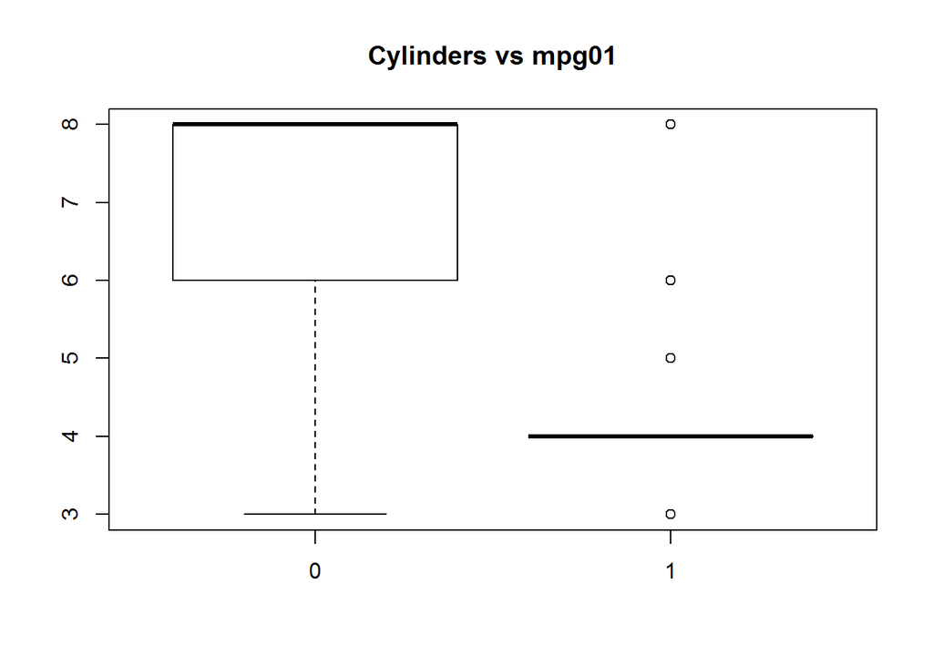

```r
boxplot(d$cylinders ~ d$mpg01, main = "Cylinders vs mpg01")
```

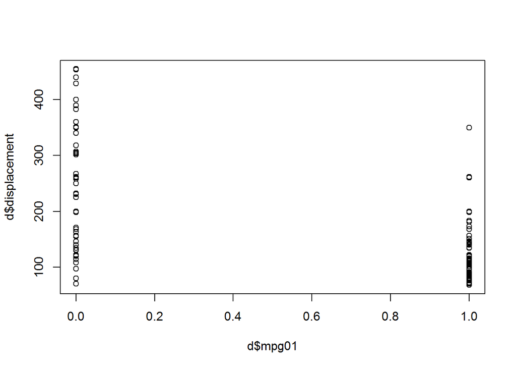

```r
plot(d$mpg01,d$displacement) #Yes useful to predict mpg01
```

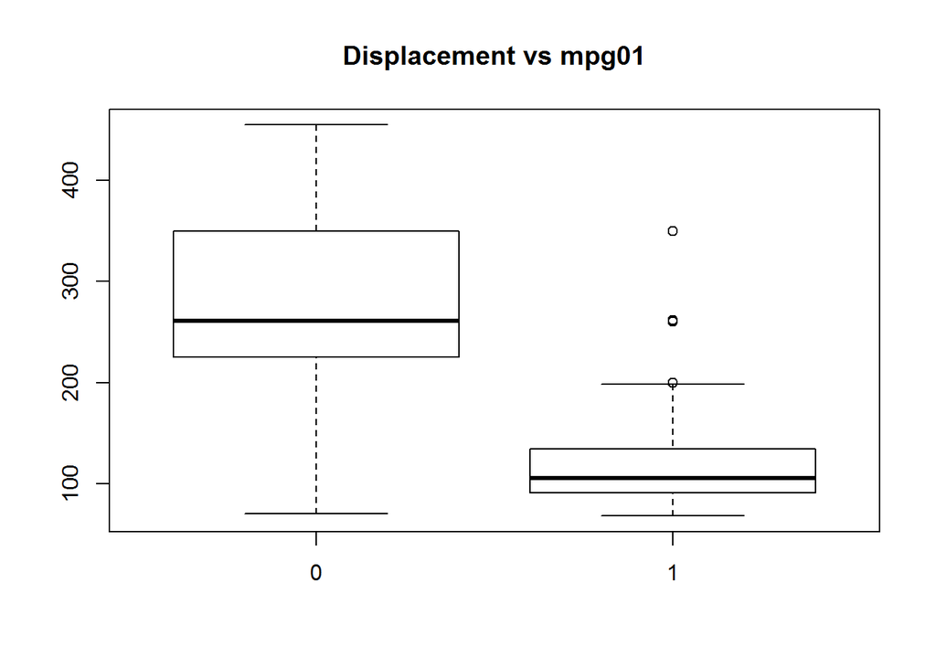

```r
boxplot(d$displacement ~ d$mpg01, main = "Displacement vs mpg01")
```

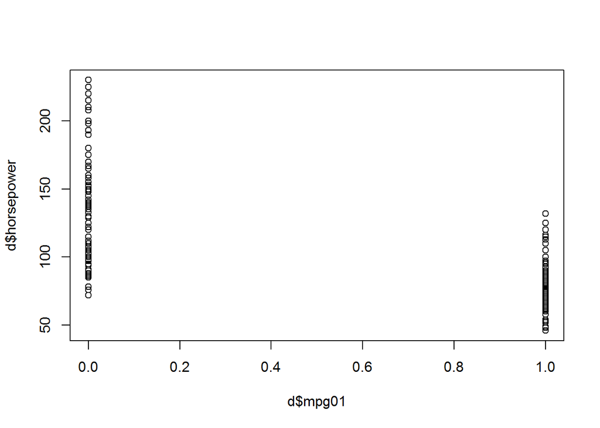

```r
plot(d$mpg01,d$horsepower) #Yes useful to predict mpg01
```

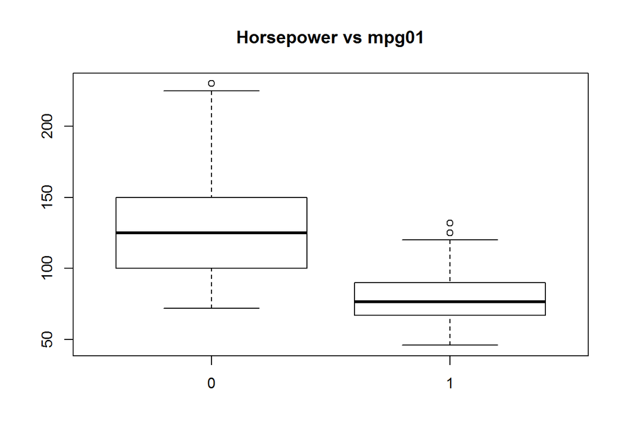

```r
boxplot(d$horsepower ~ d$mpg01, main = "Horsepower vs mpg01")
```

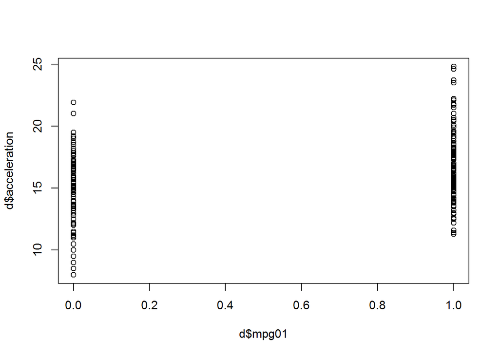

```r
plot(d$mpg01,d$acceleration) #Yes useful to predict mpg01
```

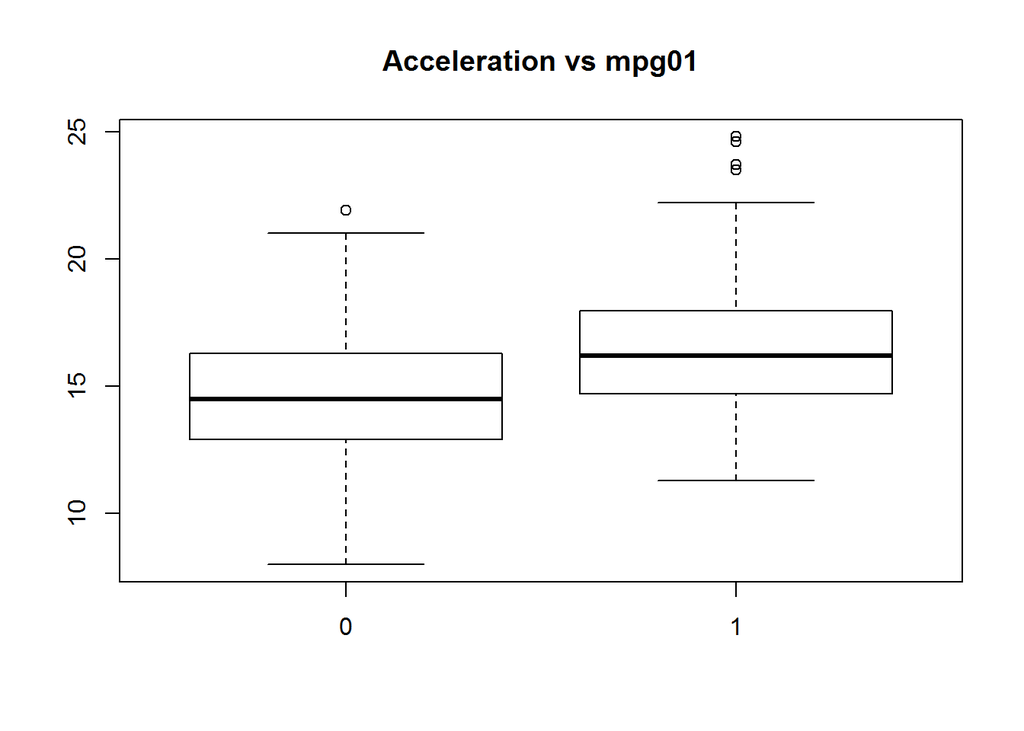

```r
boxplot(d$acceleration ~ d$mpg01, main = "Acceleration vs mpg01")
```

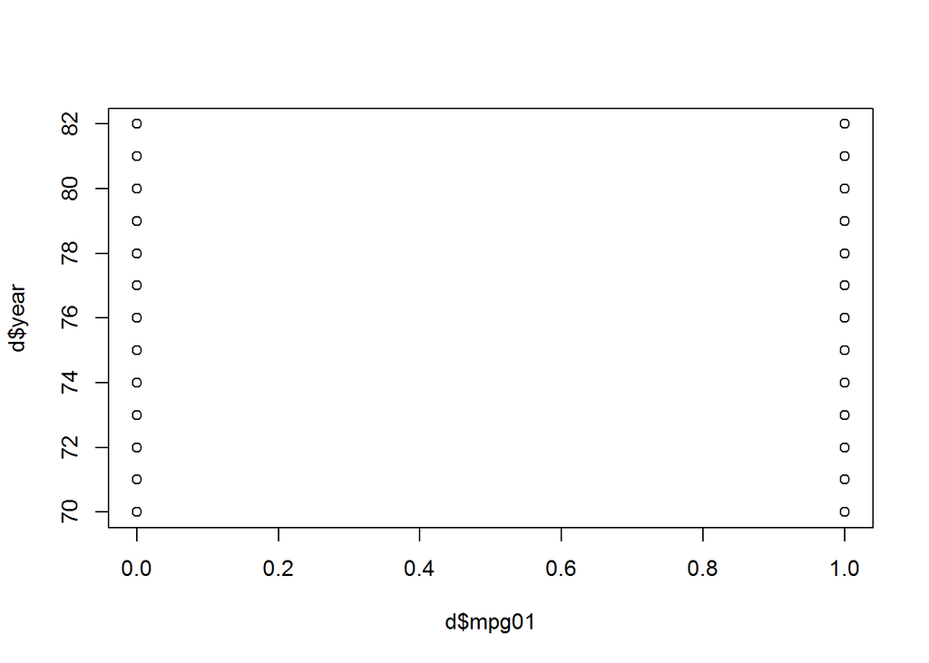

```r
plot(d$mpg01,d$year) #Not useful
```

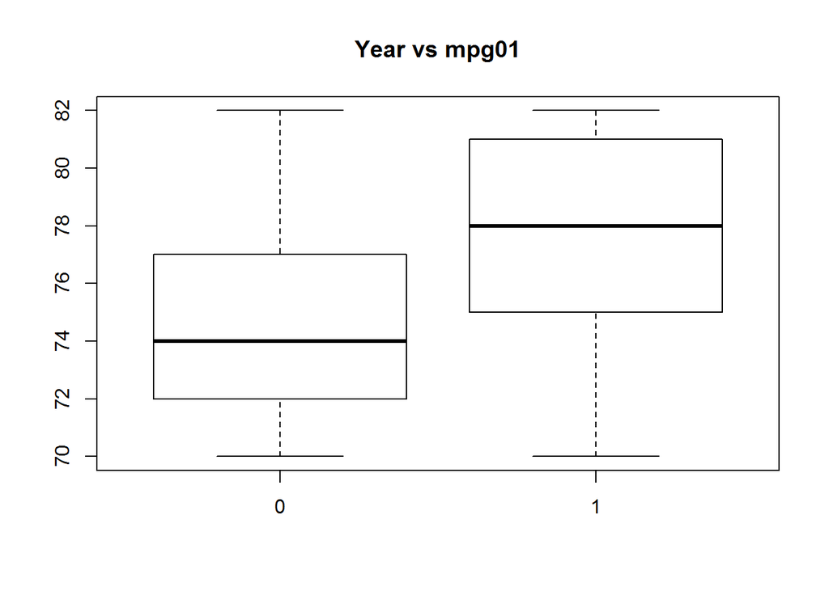

```r
boxplot(d$year ~ d$mpg01, main = "Year vs mpg01")
```

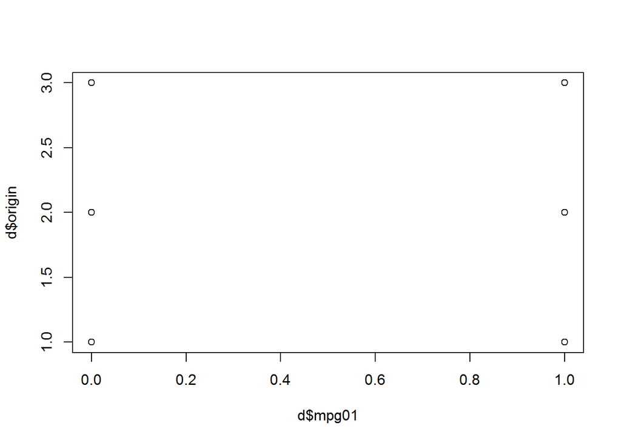

```r
plot(d$mpg01,d$origin) #Not useful
```

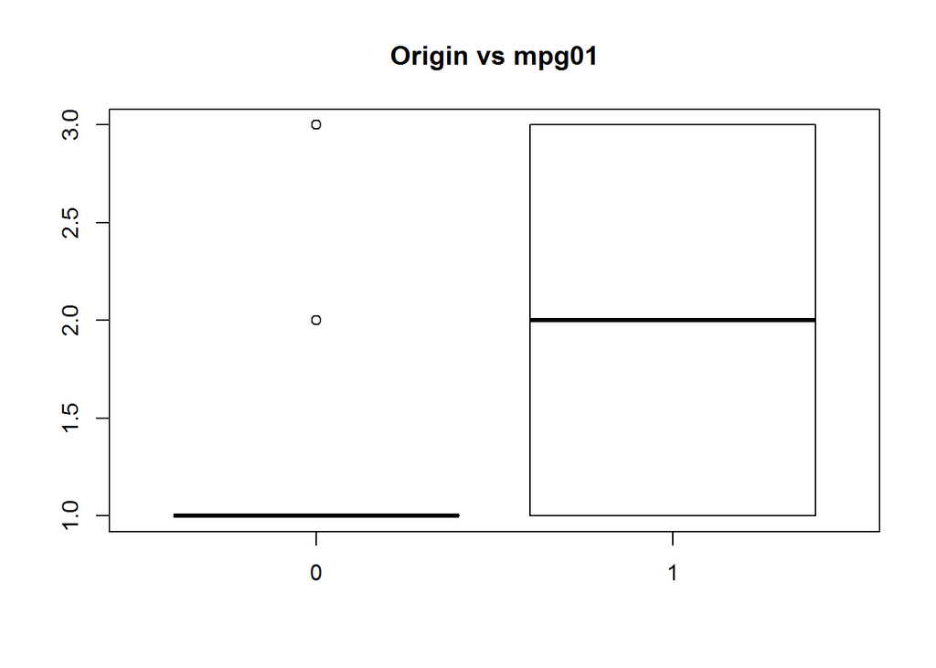

```r
boxplot(d$origin ~ d$mpg01, main = "Origin vs mpg01")
```

# 3

## (a)

Fit a logistic regression model

```r
set.seed(1)

glm.fit=glm(default~income+balance, data = Default, family = binomial)

glm.fit
```

```
##
## Call:  glm(formula = default ~ income + balance, family = binomial,
##     data = Default)
##
## Coefficients:
## (Intercept)       income      balance
##  -1.154e+01    2.081e-05    5.647e-03
##
## Degrees of Freedom: 9999 Total (i.e. Null);  9997 Residual
## Null Deviance:       2921
## Residual Deviance: 1579  AIC: 1585
```

## (b)

Split the data set

```r
set.seed(1)
train = sample(1:nrow(Default), nrow(Default)/2)
default.validation = Default[-train,]

##(ii)

glm.fit=glm(default~income+balance, data = Default, family = binomial, subset=train)

#(iii)
glm.probs=predict(glm.fit, default.validation, type="response")

glm.pred=rep("No",5000)
glm.pred[glm.probs>.5]="Yes"

##(iv)

table(glm.pred, default.validation$default)
```

```
##
## glm.pred   No  Yes
##      No  4805  115
##      Yes   28   52
```

```r
mean(glm.pred==default.validation)
```

```
## [1] 0.41845
```

```r
mean(glm.pred!=default.validation)
```

```
## [1] 0.58155
```

## (c)

Repeat with different splits - Repeat 1

```r
set.seed(1)
train = sample(1:nrow(Default), nrow(Default)/1.5)
default.validation = Default[-train,]

##(ii)

glm.fit=glm(default~income+balance, data = Default, family = binomial, subset=train)

#(iii)
glm.probs=predict(glm.fit, default.validation, type="response")

glm.pred=rep("No",3334)
glm.pred[glm.probs>.5]="Yes"

##(iv)

table(glm.pred, default.validation$default)
```

```
##
## glm.pred   No  Yes
##      No  3211   79
##      Yes   14   30
```

```r
mean(glm.pred==default.validation)
```

```
## [1] 0.4183413
```

```r
mean(glm.pred!=default.validation)
```

```
## [1] 0.5816587
```

### Repeat 2

```r
set.seed(1)
train = sample(1:nrow(Default), nrow(Default)/1.01)
default.validation = Default[-train,]

##(ii)

glm.fit=glm(default~income+balance, data = Default, family = binomial, subset=train)

#(iii)
glm.probs=predict(glm.fit, default.validation, type="response")

glm.pred=rep("No",100)
glm.pred[glm.probs>.5]="Yes"

##(iv)

table(glm.pred, default.validation$default)
```

```
##
## glm.pred No Yes
##       No 99   1
```

```r
mean(glm.pred==default.validation)
```

```
## [1] 0.4375
```

```r
mean(glm.pred!=default.validation)
```

```
## [1] 0.5625
```

### Repeat 3

```r
set.seed(1)
train = sample(1:nrow(Default), nrow(Default)/4)
default.validation = Default[-train,]

##(ii)

glm.fit=glm(default~income+balance, data = Default, family = binomial, subset=train)

#(iii)
glm.probs=predict(glm.fit, default.validation, type="response")

glm.pred=rep("No",7500)
glm.pred[glm.probs>.5]="Yes"

##(iv)

table(glm.pred, default.validation$default)
```

```
##
## glm.pred   No  Yes
##      No  7198  155
##      Yes   53   94
```

```r
mean(glm.pred==default.validation)
```

```
## [1] 0.4188
```

```r
mean(glm.pred!=default.validation)
```

```
## [1] 0.5812
```

The result show that the sample size changes do not affect the ability to correctly predict the validation/ test set results.

## (d)

```r
set.seed(1)
train = sample(1:nrow(Default), nrow(Default)/2)
default.validation = Default[-train,]

##(ii)

glm.fit=glm(default~income+balance+student, data = Default, family = binomial, subset=train)

#(iii)
glm.probs=predict(glm.fit, default.validation, type="response")

glm.pred=rep("No",5000)
glm.pred[glm.probs>.5]="Yes"

##(iv)

table(glm.pred, default.validation$default)
```

```
##
## glm.pred   No  Yes
##      No  4803  114
##      Yes   30   53
```

```r
mean(glm.pred==default.validation)
```

```
## [1] 0.41815
```

```r
mean(glm.pred!=default.validation)
```

```
## [1] 0.58185
```

Including the dummy variable student does not help reduce the error rate.

# 4

## (a)

LOOCV and Loop On the weekly data set fit a logistic regression mode that predicts Direction using Lag1 and Lag2

```r
library(ISLR)
glm.fit=glm(Direction~Lag1+Lag2, data=Weekly, family=binomial)
summary(glm.fit)
```

```
##
## Call:
## glm(formula = Direction ~ Lag1 + Lag2, family = binomial, data = Weekly)
##
## Deviance Residuals:
##    Min      1Q  Median      3Q     Max
## -1.623  -1.261   1.001   1.083   1.506
##
## Coefficients:
##             Estimate Std. Error z value Pr(>|z|)
## (Intercept)  0.22122    0.06147   3.599 0.000319 ***
## Lag1        -0.03872    0.02622  -1.477 0.139672
## Lag2         0.06025    0.02655   2.270 0.023232 *
## ---
## Signif. codes:  0 '***' 0.001 '**' 0.01 '*' 0.05 '.' 0.1 ' ' 1
##
## (Dispersion parameter for binomial family taken to be 1)
##
##     Null deviance: 1496.2  on 1088  degrees of freedom
## Residual deviance: 1488.2  on 1086  degrees of freedom
## AIC: 1494.2
##
## Number of Fisher Scoring iterations: 4
```

On the Weekly data set fit logistic regression model that predicts Direction using Lag1 and Lag2 using all but the first observation.

## (b)

```r
Weekly2 = Weekly[-1,]
glm.fit=glm(Direction~Lag1+Lag2, data=Weekly2, family=binomial)
summary(glm.fit)
```

```
##
## Call:
## glm(formula = Direction ~ Lag1 + Lag2, family = binomial, data = Weekly2)
##
## Deviance Residuals:
##     Min       1Q   Median       3Q      Max
## -1.6258  -1.2617   0.9999   1.0819   1.5071
##
## Coefficients:
##             Estimate Std. Error z value Pr(>|z|)
## (Intercept)  0.22324    0.06150   3.630 0.000283 ***
## Lag1        -0.03843    0.02622  -1.466 0.142683
## Lag2         0.06085    0.02656   2.291 0.021971 *
## ---
## Signif. codes:  0 '***' 0.001 '**' 0.01 '*' 0.05 '.' 0.1 ' ' 1
##
## (Dispersion parameter for binomial family taken to be 1)
##
##     Null deviance: 1494.6  on 1087  degrees of freedom
## Residual deviance: 1486.5  on 1085  degrees of freedom
## AIC: 1492.5
##
## Number of Fisher Scoring iterations: 4
```

Predict the direction of the first observation

## (c)

```r
glm.probs = predict(glm.fit, Weekly[1,], type = "response")
glm.probs
```

```
##         1
## 0.5713923
```

```r
Weekly[1,]
```

```
##   Year  Lag1  Lag2   Lag3   Lag4   Lag5   Volume Today Direction
## 1 1990 0.816 1.572 -3.936 -0.229 -3.484 0.154976 -0.27      Down
```

Our model predicts the direct as up but the actual direction was down, incorrect classification.

## (d)

Write a for loop from i = 1 to i = n where n is the number of observations in the data set.

```r
n = nrow(Weekly)

count = rep(0,n)

for (i in 1:n) {
  glm.fit = glm(Direction ~ Lag1 + Lag2, data = Weekly[-i,], family = binomial)
  prediction = predict.glm(glm.fit, Weekly[i,], type = "response") > 0.5
  actual = Weekly[i, ]$Direction == "Up"
  if (prediction != actual)
    count[i] = 1}

sum(count)
```

```
## [1] 490
```

## (e)

```r
mean(count)
```

```
## [1] 0.4499541
```

The LOOCV estimate for the test error is 45%.

# 5

## (a)

```r
set.seed(1)
x = rnorm(100)
y=x-2*x^2+rnorm(100)
```

n is eqaul to 100 and p is eqaul to 2.

## (b)

Create a scatter plot

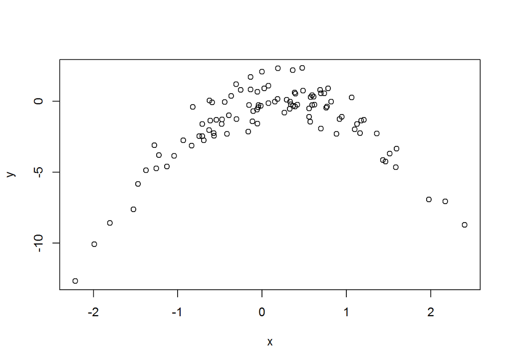

```r
plot(y~x)
```

As x approaches zero y also approaches zero, the plot shows a parabola shap plot open at the bottom

## (c)

Set a random seed, and then compute the LOOCV errors that result from fitting the following four models using least squares.

```r
library(boot)
set.seed(1)
randomdata = data.frame(x, y)
glm.fit=glm(y~x ,data=randomdata)
cv.err =cv.glm(randomdata ,glm.fit)
cv.err$delta
```

```
## [1] 7.288162 7.284744
```

```r
glm.fit=glm(y~poly(x,2), data=randomdata)
cv.err=cv.glm (randomdata ,glm.fit)
cv.err$delta
```

```
## [1] 0.9374236 0.9371789
```

```r
glm.fit=glm(y~poly(x,3), data=randomdata)
cv.err=cv.glm (randomdata ,glm.fit)
cv.err$delta
```

```
## [1] 0.9566218 0.9562538
```

```r
glm.fit=glm(y~poly(x,4), data=randomdata)
cv.err=cv.glm (randomdata ,glm.fit)
cv.err$delta
```

```
## [1] 0.9539049 0.9534453
```

## (d)

```r
set.seed(2)
XY = data.frame(x, y)
glm.fit=glm(y~x ,data=randomdata)
cv.err =cv.glm(randomdata ,glm.fit)
cv.err$delta
```

```
## [1] 7.288162 7.284744
```

```r
glm.fit=glm(y~poly(x,2), data=randomdata)
cv.err=cv.glm (randomdata ,glm.fit)
cv.err$delta
```

```
## [1] 0.9374236 0.9371789
```

```r
glm.fit=glm(y~poly(x,3), data=randomdata)
cv.err=cv.glm (randomdata ,glm.fit)
cv.err$delta
```

```
## [1] 0.9566218 0.9562538
```

```r
glm.fit=glm(y~poly(x,4), data=randomdata)
cv.err=cv.glm (randomdata ,glm.fit)
cv.err$delta
```

```
## [1] 0.9539049 0.9534453
```

My results are the same, I was expecting different two numbers in the delta vector contain the cross-validation results as the data set is different. There is a drop in the estimated test MSE between the linear and quadratic plots, no improvement with using higher-order polynomials.

## (e)

A model that predicts Y using a quadratic function of X performs better than a model that involves only a linear function of x, and there is little evidence in favor of the model that uses a cubic function of x or quartic.

## (f)

```r
summary(glm(y~x ,data=randomdata))
```

```
##
## Call:
## glm(formula = y ~ x, data = randomdata)
##
## Deviance Residuals:
##     Min       1Q   Median       3Q      Max
## -9.5161  -0.6800   0.6812   1.5491   3.8183
##
## Coefficients:
##             Estimate Std. Error t value Pr(>|t|)
## (Intercept)  -1.6254     0.2619  -6.205 1.31e-08 ***
## x             0.6925     0.2909   2.380   0.0192 *
## ---
## Signif. codes:  0 '***' 0.001 '**' 0.01 '*' 0.05 '.' 0.1 ' ' 1
##
## (Dispersion parameter for gaussian family taken to be 6.760719)
##
##     Null deviance: 700.85  on 99  degrees of freedom
## Residual deviance: 662.55  on 98  degrees of freedom
## AIC: 478.88
##
## Number of Fisher Scoring iterations: 2
```

```r
summary(glm(y~poly(x,2), data=randomdata))
```

```
##
## Call:
## glm(formula = y ~ poly(x, 2), data = randomdata)
##
## Deviance Residuals:
##     Min       1Q   Median       3Q      Max
## -1.9650  -0.6254  -0.1288   0.5803   2.2700
##
## Coefficients:
##             Estimate Std. Error t value Pr(>|t|)
## (Intercept)  -1.5500     0.0958  -16.18  < 2e-16 ***
## poly(x, 2)1   6.1888     0.9580    6.46 4.18e-09 ***
## poly(x, 2)2 -23.9483     0.9580  -25.00  < 2e-16 ***
## ---
## Signif. codes:  0 '***' 0.001 '**' 0.01 '*' 0.05 '.' 0.1 ' ' 1
##
## (Dispersion parameter for gaussian family taken to be 0.9178258)
##
##     Null deviance: 700.852  on 99  degrees of freedom
## Residual deviance:  89.029  on 97  degrees of freedom
## AIC: 280.17
##
## Number of Fisher Scoring iterations: 2
```

```r
summary(glm(y~poly(x,3), data=randomdata))
```

```
##
## Call:
## glm(formula = y ~ poly(x, 3), data = randomdata)
##
## Deviance Residuals:
##     Min       1Q   Median       3Q      Max
## -1.9765  -0.6302  -0.1227   0.5545   2.2843
##
## Coefficients:
##              Estimate Std. Error t value Pr(>|t|)
## (Intercept)  -1.55002    0.09626 -16.102  < 2e-16 ***
## poly(x, 3)1   6.18883    0.96263   6.429 4.97e-09 ***
## poly(x, 3)2 -23.94830    0.96263 -24.878  < 2e-16 ***
## poly(x, 3)3   0.26411    0.96263   0.274    0.784
## ---
## Signif. codes:  0 '***' 0.001 '**' 0.01 '*' 0.05 '.' 0.1 ' ' 1
##
## (Dispersion parameter for gaussian family taken to be 0.9266599)
##
##     Null deviance: 700.852  on 99  degrees of freedom
## Residual deviance:  88.959  on 96  degrees of freedom
## AIC: 282.09
##
## Number of Fisher Scoring iterations: 2
```

```r
summary(glm(y~poly(x,4), data=randomdata))
```

```
##
## Call:
## glm(formula = y ~ poly(x, 4), data = randomdata)
##
## Deviance Residuals:
##     Min       1Q   Median       3Q      Max
## -2.0550  -0.6212  -0.1567   0.5952   2.2267
##
## Coefficients:
##              Estimate Std. Error t value Pr(>|t|)
## (Intercept)  -1.55002    0.09591 -16.162  < 2e-16 ***
## poly(x, 4)1   6.18883    0.95905   6.453 4.59e-09 ***
## poly(x, 4)2 -23.94830    0.95905 -24.971  < 2e-16 ***
## poly(x, 4)3   0.26411    0.95905   0.275    0.784
## poly(x, 4)4   1.25710    0.95905   1.311    0.193
## ---
## Signif. codes:  0 '***' 0.001 '**' 0.01 '*' 0.05 '.' 0.1 ' ' 1
##
## (Dispersion parameter for gaussian family taken to be 0.9197797)
##
##     Null deviance: 700.852  on 99  degrees of freedom
## Residual deviance:  87.379  on 95  degrees of freedom
## AIC: 282.3
##
## Number of Fisher Scoring iterations: 2
```

The coefficient estimates support the cross validation conculsions.